# Happy Hotel

by Daniel Gole

```python
# basic
import sys
import numpy        as np
import numpy.random as npr
import pandas       as pd
import pandas_profiling
import scipy
from   matplotlib               import pyplot as plt
import seaborn as sns
# sklearn tools
import sklearn.metrics          as sklm
import sklearn.preprocessing    as sklp
import sklearn.datasets         as skld
from   sklearn.model_selection  import train_test_split
# sklearn regression models
from   sklearn.linear_model     import LinearRegression
from   sklearn.ensemble         import RandomForestRegressor
from   sklearn.neighbors        import KNeighborsRegressor
# sklearn classifiers
from   sklearn.linear_model     import LogisticRegression
from   sklearn.ensemble         import RandomForestClassifier
from   sklearn.neighbors        import KNeighborsClassifier
# sklearn clustering and unsupervised
from   sklearn.cluster          import KMeans
from   sklearn.decomposition    import PCA
# NLP
import nltk
import gensim
from   gensim.utils             import simple_preprocess
from   gensim.parsing.preprocessing import STOPWORDS
from   nltk.stem                import WordNetLemmatizer
from   nltk.stem                import SnowballStemmer
from   nltk.stem.porter         import *
import pyLDAvis
import pyLDAvis.gensim
nltk.download('wordnet')
stemmer = SnowballStemmer("english")
# my stuff
#sys.path.append('../snippets/')
#import ml
#import plotting
# hosekeeping
import warnings
warnings.filterwarnings('ignore')
%matplotlib inline
npr.seed(0)
data_path = "../data/HappyHotel/"
```

```python
%%javascript
IPython.OutputArea.prototype._should_scroll = function(lines) {
    return false;
}
```

## Read Data

```python
file_name_hap    = 'hotel_happy_reviews.csv'
file_name_nhap = 'hotel_not_happy_reviews.csv'
df_hap  = pd.read_csv(data_path + file_name_hap)
df_nhap = pd.read_csv(data_path + file_name_nhap)
df = df_hap.append(df_nhap)
```

## Simple EDA

```python
#df.describe()
#pandas_profiling.ProfileReport(df)
#df.head()
df = df.reset_index()
print(df.index)
df.head()
```

```
RangeIndex(start=0, stop=38932, step=1)
```

|  | index | User_ID | Description | Is_Response | hotel_ID |
| --- | --- | --- | --- | --- | --- |
| 0 | 0 | id10329 | Stayed here with husband and sons on the way t... | happy | 8 |
| 1 | 1 | id10331 | We had - rooms. One was very nice and clearly ... | happy | 3 |
| 2 | 2 | id10333 | My wife & I stayed in this glorious city a whi... | happy | 3 |
| 3 | 3 | id10334 | My boyfriend and I stayed at the Fairmont on a... | happy | 7 |
| 4 | 4 | id10336 | Steps off Times Square, nice rooms, stayed - n... | happy | 3 |

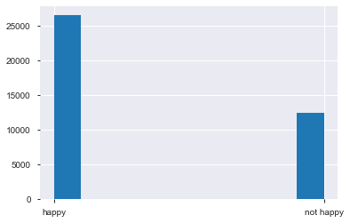

```python
df['Is_Response'].hist()
```

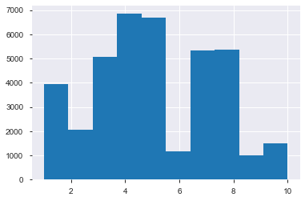

```python
df['hotel_ID'].hist()
```

```python
def add_is_hap_to_df(df):
    vals = df['Is_Response'].values
    res  = np.where(vals=='happy',1,0)
    df['is_hap'] = res
    res  = np.where(vals=='not happy',1,0)
    df['is_nhap'] = res
    return df
```

```python
df = add_is_hap_to_df(df)
```

## NLP Preprocessing

I'm following the guide at the following link pretty closely to do LDA and topic modeling on the dataset.  
https://www.analyticsvidhya.com/blog/2018/10/mining-online-reviews-topic-modeling-lda/  
The basic procedure is:

1. Split each review into a list of words
2. "Lematize" each word: reduce it to it's root word
3. Remove stopwords from a database of stopwords. These are words that don't really add information (and, the, etc.)

```python
def lemmatize_stemming(text):
    return stemmer.stem(WordNetLemmatizer().lemmatize(text, pos='v'))
# Tokenize and lemmatize
def preprocess(text, exclude_words):
    result=[]
    for token in gensim.utils.simple_preprocess(text) :
        if token not in gensim.parsing.preprocessing.STOPWORDS and len(token) > 3:
            res = lemmatize_stemming(token)
            if res not in exclude_words:
                result.append(res)
    return result
```

```python
df['preproc_Description'] = df['Description'].apply(preprocess, args=([],))
df.head()
```

|  | index | User_ID | Description | Is_Response | hotel_ID | is_hap | is_nhap | preproc_Description |
| --- | --- | --- | --- | --- | --- | --- | --- | --- |
| 0 | 0 | id10329 | Stayed here with husband and sons on the way t... | happy | 8 | 1 | 0 | [stay, husband, son, alaska, cruis, love, hote... |
| 1 | 1 | id10331 | We had - rooms. One was very nice and clearly ... | happy | 3 | 1 | 0 | [room, nice, clear, updat, recent, clean, comf... |
| 2 | 2 | id10333 | My wife & I stayed in this glorious city a whi... | happy | 3 | 1 | 0 | [wife, stay, glorious, citi, expens, littl, ho... |
| 3 | 3 | id10334 | My boyfriend and I stayed at the Fairmont on a... | happy | 7 | 1 | 0 | [boyfriend, stay, fairmont, recent, trip, fran... |
| 4 | 4 | id10336 | Steps off Times Square, nice rooms, stayed - n... | happy | 3 | 1 | 0 | [step, time, squar, nice, room, stay, night, g... |

## Topic Modeling

1. Use gensim to make a dictionary of words --> integer mapping over all the reviews
2. Create a word count frequency matrix for each individual review

```python
class LDA_wrapper():
    def __init__(self, df, col, n_topics):
        self.n_topics        = n_topics
        self.corpus_all      = df[col].as_matrix()
        self.dictionary      = gensim.corpora.Dictionary(self.corpus_all)
        self.doc_term_matrix = [self.dictionary.doc2bow(rev) for rev in df[col]]
        LDA                  = gensim.models.ldamodel.LdaModel
        self.lda_model       = LDA(corpus=self.doc_term_matrix,
                                   id2word = self.dictionary,
                                   num_topics=self.n_topics,
                                   random_state=0,
                                   )
```

```python
def make_LDA_viz(lda_wrapper):
    pyLDAvis.enable_notebook()
    viz = pyLDAvis.gensim.prepare(lda_wrapper.lda_model,
                                  lda_wrapper.doc_term_matrix,
                                  lda_wrapper.dictionary)
    return viz
```

Do an LDA with an arbitrarily chosen number of topics. I'll start with 10.

```python
lda_10 = LDA_wrapper(df, 'preproc_Description', 10)
```

```python
viz = make_LDA_viz(lda_10)
viz
```

[interactive chart not shown]

### Remove common and unhelpful words

```python
ex_words = ['hotel', 'stay', 'good', 'great', 'night', 'nice']
df['preproc_Description_exwords'] = df['Description'].apply(preprocess, args=(ex_words,))
df.head()
```

|  | index | User_ID | Description | Is_Response | hotel_ID | is_hap | is_nhap | preproc_Description | preproc_Description_exwords |
| --- | --- | --- | --- | --- | --- | --- | --- | --- | --- |
| 0 | 0 | id10329 | Stayed here with husband and sons on the way t... | happy | 8 | 1 | 0 | [stay, husband, son, alaska, cruis, love, hote... | [husband, son, alaska, cruis, love, experi, ro... |
| 1 | 1 | id10331 | We had - rooms. One was very nice and clearly ... | happy | 3 | 1 | 0 | [room, nice, clear, updat, recent, clean, comf... | [room, clear, updat, recent, clean, comfi, nee... |
| 2 | 2 | id10333 | My wife & I stayed in this glorious city a whi... | happy | 3 | 1 | 0 | [wife, stay, glorious, citi, expens, littl, ho... | [wife, glorious, citi, expens, littl, super, l... |
| 3 | 3 | id10334 | My boyfriend and I stayed at the Fairmont on a... | happy | 7 | 1 | 0 | [boyfriend, stay, fairmont, recent, trip, fran... | [boyfriend, fairmont, recent, trip, francisco,... |
| 4 | 4 | id10336 | Steps off Times Square, nice rooms, stayed - n... | happy | 3 | 1 | 0 | [step, time, squar, nice, room, stay, night, g... | [step, time, squar, room, short, visit] |

```python
lda_10_exwords = LDA_wrapper(df, 'preproc_Description_exwords', 10)
```

```python
viz = make_LDA_viz(lda_10_exwords)
viz
```

[interactive chart not shown]

### Reduce to appropriate number of topics

```python
lda_4_exwords = LDA_wrapper(df, 'preproc_Description_exwords', 4)
```

```python
viz = make_LDA_viz(lda_4_exwords)
viz
```

[interactive chart not shown]

```python
lda_3_exwords = LDA_wrapper(df, 'preproc_Description_exwords', 3)
```

```python
viz = make_LDA_viz(lda_3_exwords)
viz
```

[interactive chart not shown]

## Topic Interpretation

Using the visualization above I assigned intuitive topic names for each of the topics found by the LDA

```python
n_topics = 3
topic_names = ['Room, Bathroom, Floor', 'Staff and Service', 'Location and Ammenities']
```

### Get the "amount of each topic in each review" and assign to dataframe

```python
topic_matrix = np.zeros([len(df), n_topics])
for i in range(len(df)):
    res = lda_3_exwords.lda_model.get_document_topics(lda_3_exwords.doc_term_matrix[i], minimum_probability=0.0)
    res = np.asarray([res[i][1] for i in range(len(res))])
    topic_matrix[i,:] = res
for n in range(n_topics):
    df['topic_'+str(n)] = topic_matrix[:,n]
```

### Compute a simple metric:

For each hotel, calculate:  
happiness by topic = total amount of topic in happy reviews / total amount of topic in all reviews  
unhappiness by topic = total amount of topic in unhappy reviews / total amount of topic in all reviews  
topic score = happiness in the topic - unhappiness in that topic adjusted score = topic score for given hotel - average topic score across all hotels

```python
df_results = pd.DataFrame(index = df['hotel_ID'].unique())
df_results.sort_index(inplace=True)
for hid in df_results.index:
    df_all  = df.loc[df['hotel_ID']==hid]
    df_hap  = df_all.loc[df_all['is_hap']==1]
    df_nhap = df_all.loc[df_all['is_hap']==0]
    for n in range(n_topics):
        df_results.set_value(hid, 'happy_topic_'+str(n), df_hap['topic_'+str(n)].mean()/df_all['topic_'+str(n)].mean())
    for n in range(n_topics):
        df_results.set_value(hid, 'nhappy_topic_'+str(n), df_nhap['topic_'+str(n)].mean()/df_all['topic_'+str(n)].mean())
```

```python
df_results
```

|  | happy_topic_0 | happy_topic_1 | happy_topic_2 | nhappy_topic_0 | nhappy_topic_1 | nhappy_topic_2 |
| --- | --- | --- | --- | --- | --- | --- |
| 1 | 0.518832 | 1.221094 | 1.422365 | 1.599123 | 0.724707 | 0.474096 |
| 2 | 0.472327 | 1.297802 | 1.481686 | 1.545401 | 0.692193 | 0.502130 |
| 3 | 0.578202 | 1.165317 | 1.277136 | 1.907965 | 0.644137 | 0.403436 |
| 4 | 0.594843 | 1.160624 | 1.272877 | 1.858099 | 0.659807 | 0.422063 |
| 5 | 0.731890 | 1.083350 | 1.126913 | 2.300638 | 0.595657 | 0.384325 |
| 6 | 0.613367 | 1.146307 | 1.239871 | 1.952691 | 0.639488 | 0.408940 |
| 7 | 0.519595 | 1.228753 | 1.406568 | 1.631133 | 0.699475 | 0.465871 |
| 8 | 0.739561 | 1.074478 | 1.122066 | 2.379716 | 0.605441 | 0.353338 |
| 9 | 0.466674 | 1.259626 | 1.497561 | 1.566451 | 0.724248 | 0.471534 |
| 10 | 0.518986 | 1.282086 | 1.432154 | 1.509193 | 0.701388 | 0.542530 |

```python
#df_diffs = df_results[['diff_topic_'+str(n) for n in range(n_topics)]]
df_diffs = df_diffs - df_diffs.mean()
df_diffs = df_diffs / df_diffs.abs().max()
df_diffs
```

[output not shown]

```python
def make_topic_happiness_plot(df_diffs, n_topics=3):
    fig = plt.figure(figsize=(6,4), dpi=150)
    x0  = (n_topics+3)*np.arange(len(df_diffs))
    for i in range(n_topics):
        plt.bar(x0+i+0.5, df_diffs['diff_topic_'+str(i)].values, label=topic_names[i])
    #for i in range(len(df)):
        #plt.axvline(x=x0[i]+n_topics+0.5, color='k')
    plt.xticks(x0+float(n_topics)/2.0, df_diffs.index , rotation=0)
    #plt.ylabel('Freq in Pos Revs - Freq in Neg Revs')
    plt.xlabel('Hotel ID')
    plt.axhline(y=0, color='k')
    plt.title('Hotel Performance by Topic')
    plt.ylim(-1.5, 1.5)
    plt.text(6, 1.25,  "reviews on this topic were happier than average", fontsize=11)
    plt.text(6, -1.35, "reviews on this topic were less happy than average", fontsize=11)
    plt.legend(loc=(1.01, 0.7))
    return plt
```

```
<module 'matplotlib.pyplot' from '/home/dgole/anaconda3/envs/insight/lib/python3.7/site-packages/matplotlib/pyplot.py'>
```

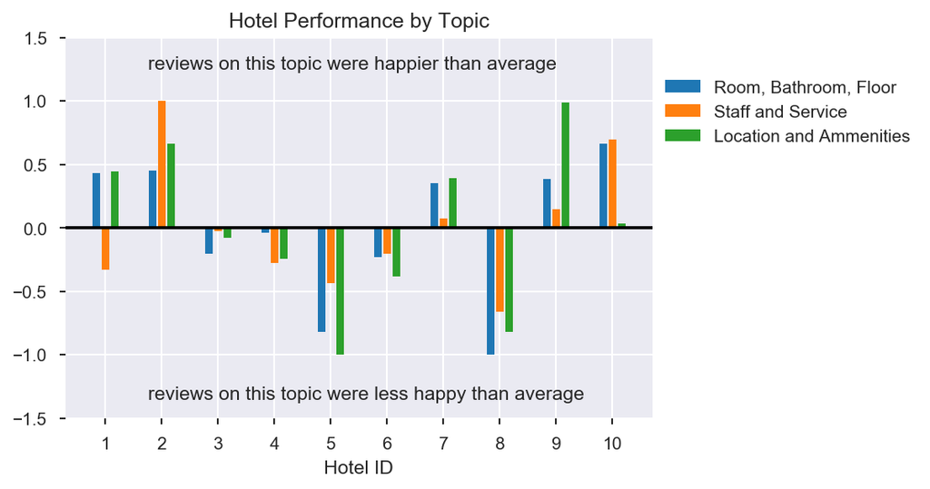

```python
make_topic_happiness_plot(df_diffs)
```